# Ford GoBike data analysis

## by Bertrand B

## Investigation Overview

> In my investigation I want to explore this dataset to undersatnd the differents part of It. I will show trends in the dataset, the interesting fact we can get out of It. In this case I want to show the different place someone will got to using the ford GoBike, the duration of his trips and more info about It.

## Dataset Overview

> This dataset is composed of users of GoBike application by ford wich register your trip, the duration of It, the localistion of It (using lat and longitude) and the type of users.

## Univariate Visualization

> The next visualization are univariates one to understand the variables well before computing It with other variables. I will plot the start hour, the end hour (of the trip), the type of user and the duration of the trip.

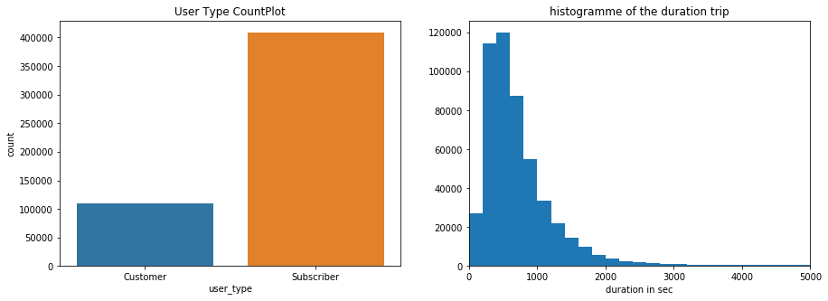

```python
plt.figure(figsize=[23,5])
plt.subplot(1,3,1)
sb.countplot(data=df,x='user_type')
plt.title('User Type CountPlot')

plt.subplot(1,3,2)
bins=np.arange(0, df.duration_sec.max()+200,200)
plt.hist(data=df,x='duration_sec',bins=bins);
plt.xlim([0,5000])
plt.xlabel('duration in sec')
plt.title('histogramme of the duration trip');
```

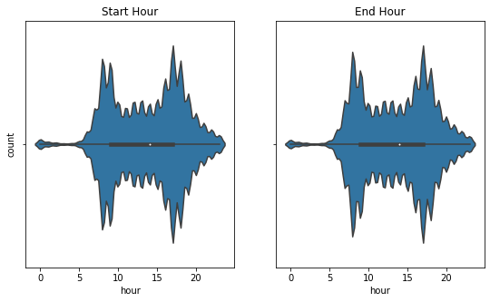

```python
df_hour_e=pd.DataFrame()
df_hour_s=pd.DataFrame()
df_hour_e['hour']=pd.to_datetime(df.start_time).dt.hour
df_hour_s['hour']=pd.to_datetime(df.end_time).dt.hour
plt.figure(figsize=[14,5])
plt.subplot(1,3,1)
sb.violinplot(data=df_hour_s,x='hour')
plt.ylabel('count')
plt.title('Start Hour')

plt.subplot(1,3,2)
sb.violinplot(data=df_hour_e,x='hour',bins=np.arange(0,24,1));
plt.title('End Hour');
```

## Positions of the trips

> With the longitude and the latitude we can plot the position on a 2D graph or even more with a web tool like kepler.

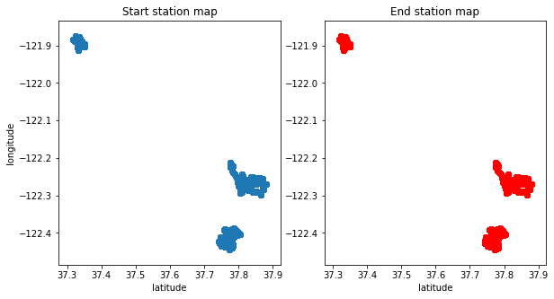

```python
plt.figure(figsize=[15,5])
plt.subplot(1,3,1)
plt.scatter(data=df,x='start_station_latitude',y='start_station_longitude',color=sb.color_palette()[0]);
plt.title('Start station map')
plt.xlabel('latitude')
plt.ylabel('longitude')
plt.subplot(1,3,2)
plt.title('End station map')
plt.xlabel('latitude')
plt.scatter(data=df,x='end_station_latitude',y='end_station_longitude',color='r');
```

We can see the three main positions, OKAY, but where is It in real life ?

[figure not shown]

```python
from IPython.display import Image
Image("kepler-gl.png")
```

[figure not shown]

```python
Image("kepler-gl (1).png")
```

The positions are now revealed, we can see the three main positions andwe can put names on It : Oakland, San Fransisco and San José. I computed this using a web tool Kepler.

## Distance of the trips by user types

> We can plot the distance that I computed by the different users and by categories of positions. Now wa have the three positions that I assigned 'San Fransisco', 'Oakland' and 'San José'.

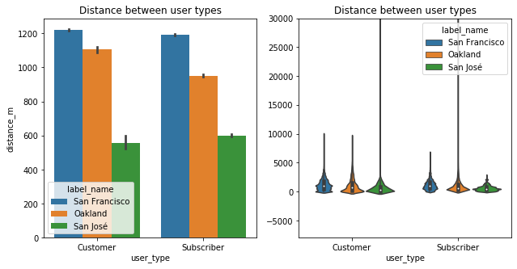

```python
plt.figure(figsize=[16,5])
plt.subplot(1,3,1)
sb.barplot(data=df,x='user_type',y='distance_m',hue='label_name');
plt.title('Distance between user types')
plt.subplot(1,3,2)
sb.violinplot(data=df,x='user_type',y='distance_m',hue='label_name');
plt.ylabel('')
plt.ylim([-8000,30000])
plt.title('Distance between user types');
```